# L2P2: Uma análise bem maior

Igor Dantas Rocha

8 de maio de 2019

## 1. Qual é a nossa taxa de cliques geral diária? Como isso varia entre os grupos?

A taxa de cliques geral diária por sesão gira em torno de 38,8%. No gráfico 2 desta seção (entitulado ‘Taxa de cliques em geral’) é possível observar a taxa de cliques por dia. Nota-se que este valor varia pouco entre os dias. No gráfico 1 desta seção (entitulado ‘Taxa de cliques por grupo’) é possível observar uma grande diferença entre as taxas de cliques dos grupos A e B. A taxa de cliques por sessão do grupo A gira em torno de 66%, enquanto a taxa do grupo B gira em torno de 19%.

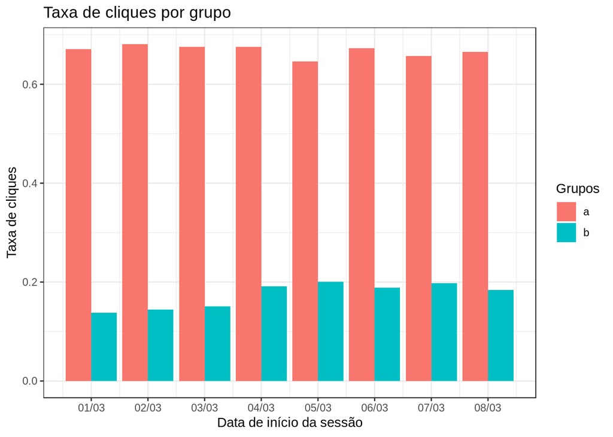

```r
clicks_date = searches %>%
    ungroup() %>%
    mutate(session_start_date = as.Date(session_start_date)) %>%
    group_by(session_id, session_start_date, group) %>%
    summarise(search_index = max(search_index),
              is_there_click = ifelse(sum(num_clicks) > 0,
                                      1,
                                      0))

click_rate = clicks_date %>%
    group_by(session_start_date) %>%
    summarise(clickthrough_rate = sum(is_there_click) / n())

click_rate_group = clicks_date %>%
    group_by(session_start_date, group) %>%
    arrange(session_start_date) %>%
    summarise(clickthrough_rate = sum(is_there_click) / n())

ggplot(data = click_rate_group) +
    theme_bw() + scale_x_date(date_labels = "%d/%m", date_breaks = "1 day") +
    geom_col(mapping = aes(x=session_start_date, y=clickthrough_rate, fill = group), position = "dodge") +
    labs(title = "Taxa de cliques por grupo",
         x = "Data de início da sessão",
         y = "Taxa de cliques",
         fill = "Grupos")
```

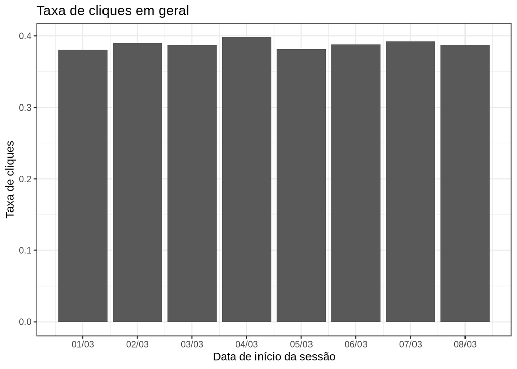

```r
ggplot(data = click_rate) +
    theme_bw() + scale_x_date(date_labels = "%d/%m", date_breaks = "1 day") +
    geom_col(mapping = aes(x=session_start_date, y=clickthrough_rate)) +
    labs(title = "Taxa de cliques em geral",
         x = "Data de início da sessão",
         y = "Taxa de cliques")
```

## 2. Quais resultados a pessoa tende a tentar primeiro? Como isso muda no dia-a-dia?

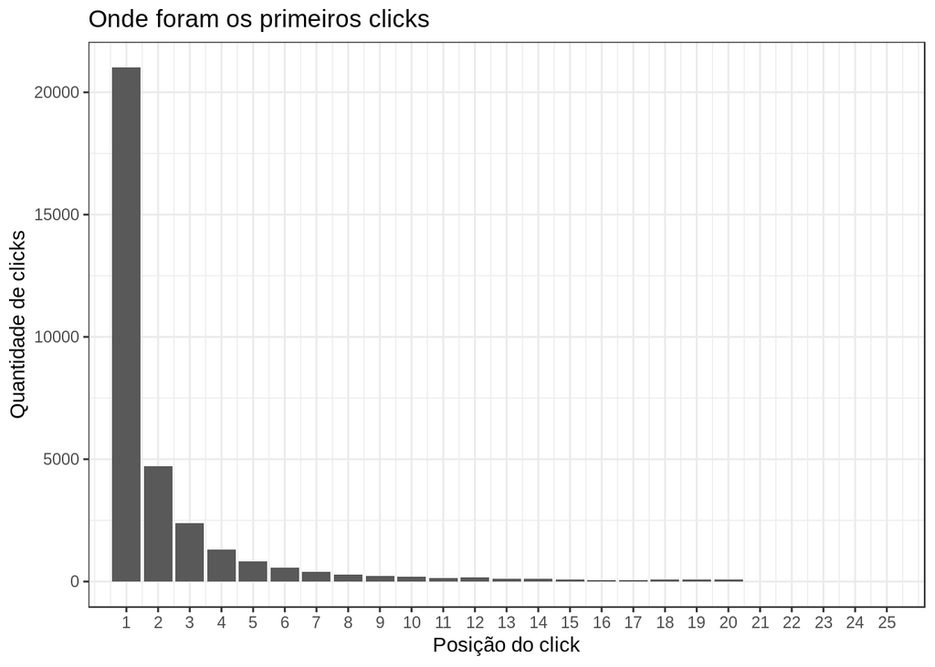

```r
searches_date = searches %>%
    ungroup() %>%
    mutate(session_start_date = as.Date(session_start_date)) %>%
    group_by(session_id)

first_click_tbl = searches_date %>%
    filter(!is.na(first_click)) %>%
    group_by(first_click)


first_click_trend = first_click_tbl %>%
    summarise(count_clicks = n()) %>%
    arrange(desc(count_clicks))

first_click_by_day = searches_date %>%
    filter(!is.na(first_click)) %>%
    group_by(first_click, session_start_date) %>%
    summarise(count = n())

first_click_perc = searches_date %>%
    filter(!is.na(first_click)) %>%
    group_by(session_start_date) %>%
    summarise(percentil_95 = quantile(first_click, probs = c(0.95)))

ggplot(data = first_click_trend) +
    theme_bw() +
    geom_col(mapping = aes(x = first_click ,y=count_clicks), bins = 300) +
    scale_x_continuous(breaks=seq(1,25,1)) +
    coord_cartesian(xlim = c(1, 25)) +
    labs(
        title = "Onde foram os primeiros clicks",
        x = "Posição do click",
        y = "Quantidade de clicks")
```

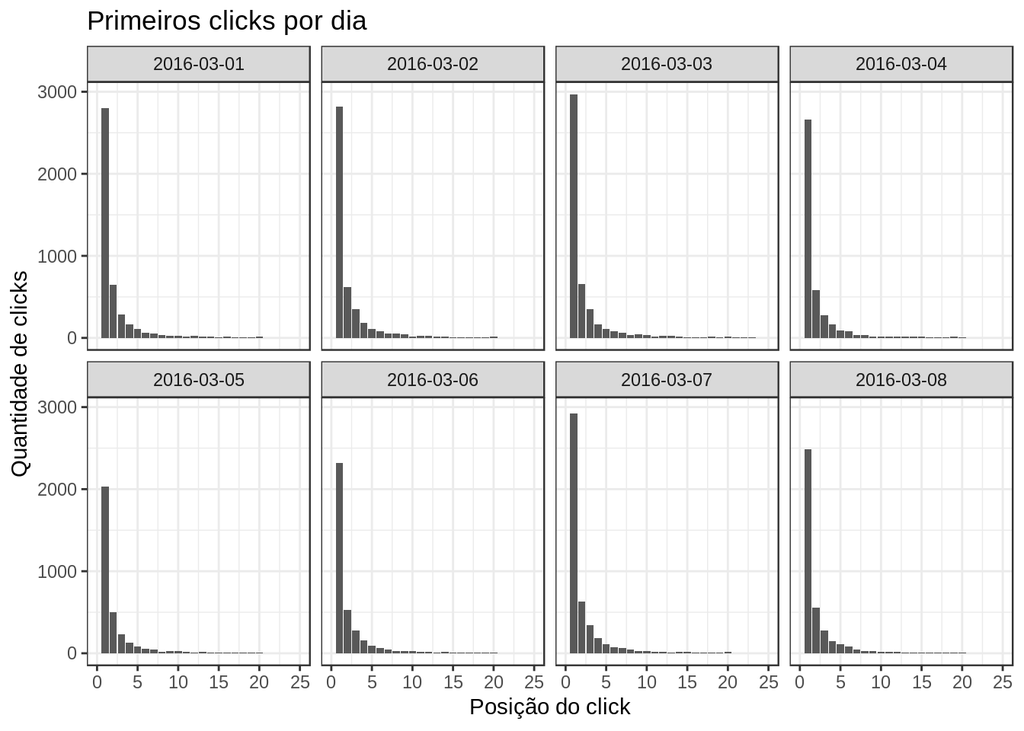

```r
ggplot(data = first_click_by_day) +
    theme_bw() +
    geom_col(mapping = aes(x=first_click, y=count), bins = 380) +
    coord_cartesian(xlim = c(0, 25)) +
    facet_wrap(~ session_start_date, nrow = 2) +
    labs(x = "Posição do click",
         y = "Quantidade de clicks",
         title = "Primeiros clicks por dia")
```

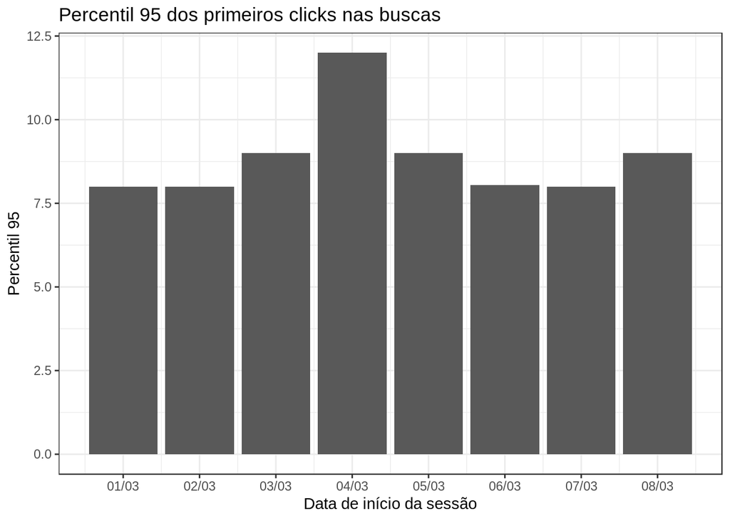

```r
ggplot(data = first_click_perc) +
    theme_bw() + scale_x_date(date_labels = "%d/%m", date_breaks = "1 day") +
    geom_col(mapping = aes(x=session_start_date, y=percentil_95)) +
    labs(title = "Percentil 95 dos primeiros clicks nas buscas ",
         x = "Data de início da sessão",
         y = "Percentil 95")
```

## 3. Qual é a nossa taxa de resultados zero no geral? Como isso varia entre os grupos?

Pode-se observar na tabela 1 desta seção que a taxa de buscas com nenhum resultado foi de 18,4%. Na tabela 2 é possível observar as taxas de cada grupo separadamente. Nota-se que as taxas são bem próximas entre os grupos, com valores girando na casa dos 18%. O gráfico 3 (entitulado “Taxas de buscas sem resultaods nos grupos”) é apenas outra maneira de mostrar a informação que é apresentada na tabela 2.

```r
zero_rate_tbl = searches %>%
    ungroup() %>%
    summarise(zero_results_rate = sum(results == 0) / n())

zero_rate_by_group = searches %>%
    group_by(group) %>%
    summarise(zero_results_rate = sum(results == 0) / n())

zero_rate_tbl
```

```
## # A tibble: 1 x 1
##   zero_results_rate
##               <dbl>
## 1             0.184
```

```r
zero_rate_by_group
```

```
## # A tibble: 2 x 2
##   group zero_results_rate
##   <chr>             <dbl>
## 1 a                 0.184
## 2 b                 0.186
```

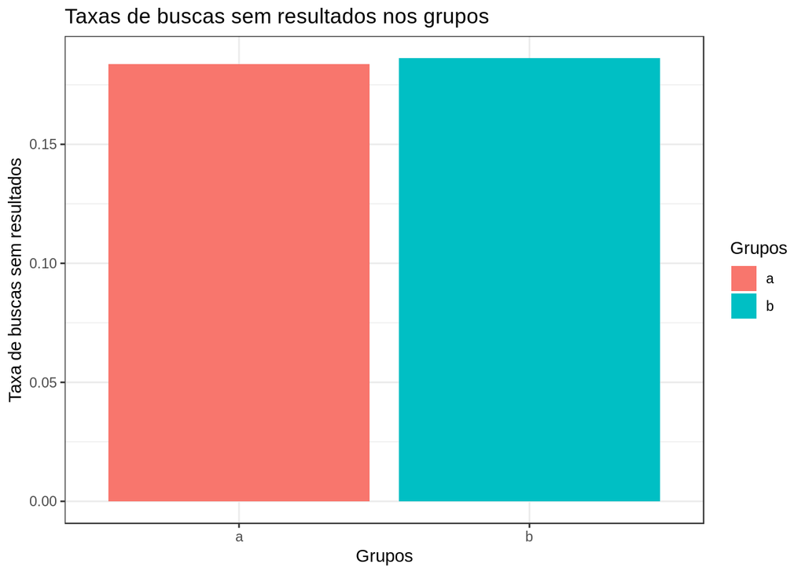

```r
ggplot(data = zero_rate_by_group) +
    theme_bw() +
    geom_col(mapping = aes(x = group, y=zero_results_rate, fill = group), position = "dodge") +
    labs(title = "Taxas de buscas sem resultados nos grupos",
         x = "Grupos",
         y = "Taxa de buscas sem resultados",
         fill = "Grupos")
```

## 4. A duração da sessão é aproximadamente o tempo entre o primeiro e o último evento de uma sessão. Escolha uma variável do conjunto de dados e descreva sua relação com o tamanho da sessão. Visualize o relacionamento.

A variável escolhida foi o número de buscas na sessão. Ao calcular a correlação entre estas variáveis pelo método de pearson (Informação que pode ser obtida na tabela mostrada a seguir desta seção) encontra-se um valor de 0.077 e, se houver uma análise precipitada, pode-se tender a afirmar que não há relação entre estas duas variáveis. Mas ao plotar o gráfico de dispersão entre as variáveis `Duração da sessão` e `Número de buscas da sessão` em uma escala logarítmica, observa-se claramente uma relação entre estas duas variáveis. Utilizando o método de spearman e o de kendall (Valores podem ser observados na tabela a seguir) encontra valores de correlação entre 0,5 e 0,6, condizente com o que se pode observar no gráfico abaixo (entitulado “Duração da sessão x Número de buscas”). Ao observar o gráfico e esses valores de correlação, é possível afirmar que há uma tendência de os números de busca na sessão serem maiores a medida que o tempo de duração da sessão aumenta.

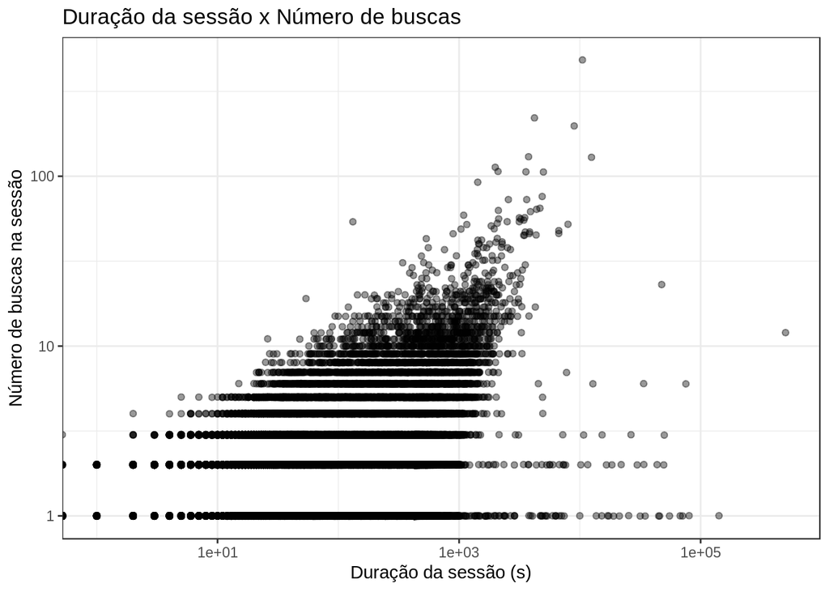

```r
searches_length = searches %>%
    group_by(session_id) %>%
    summarise(session_length = max(session_length),
              search_index = max(search_index))

ggplot(data = searches_length, mapping = aes(x = session_length, y = search_index)) +
    geom_point(position = "jitter", alpha = 4/10) +
    scale_x_log10() + scale_y_log10() + theme_bw() +
    labs(
        title = "Duração da sessão x Número de buscas",
        x = "Duração da sessão (s)",
        y = "Número de buscas na sessão"
    )
```

```r
searches_length %>%
    summarise(pearson = cor(session_length, search_index, method = 'pearson'),
              spearman = cor(session_length, search_index, method = 'spearman'),
              kendall = cor(session_length, search_index, method = 'kendall'))
```

```
## # A tibble: 1 x 3
##   pearson spearman kendall
##     <dbl>    <dbl>   <dbl>
## 1  0.0775    0.597   0.508
```